# Phylodynamics exercises: simulation of genealogy processes

Aaron A. King

## Preliminaries

Grenfell et al. (2004) showed that the shapes of genealogies of pathogen samples contain information about the processes that gave rise to them. In these exercises, you’ll explore this idea by simulating the genealogy processes induced by various pathogen transmission models and observing their shapes.

The **R** codes shown in this document are available for download. Save a copy of these codes for use as a template in your own work on the exercises.

The following code chunk loads the packages we’ll need, sets the random seed, and makes some stylistic choices. It also creates a directory to hold some of the graphics files we will be creating.

```r
set.seed(517218506L)
library(tidyverse)
library(phylopomp)
library(gifski)
theme_set(theme_bw())
dir.create("figs")
```

## The Moran process

The earliest phylodynamics methods (Rasmussen, Ratmann, and Koelle 2011; Volz, Kosakovsky Pond, Ward, Leigh Brown, and Frost 2009) were based on the so-called Kingman coalescent (Kingman 1982b, 1982a). The Kingman coalescent is a stochastic process that generates genealogies. It is typically viewed backward in time, as a process whereby lineages coalesce at random times.

In its simplest form, it has only two parameter, a population size, $n$, and a *coalescence rate*, $\mu$.

Interestingly, the coalescent is related to another classical model of population genetics, the so-called *Moran process* (King, Lin, and Ionides 2020; Moran 1958). The Moran process is very easily described: A population of $n$ individuals experiences random events at rate $\mu$. At each event, a random member of the population gives birth to a new lineage. Simultaneously, a second random member of the population dies. Thus the population size remains constant. All the members of the population are equally likely to be selected for either of these two roles: they are said to be *exchangeable*.

King et al. (2020) show how one can make this connection precise. In particular, they show how one can simulate the Moran genealogy process. The simulator is implemented as part of the **phylopomp** package. Here is the help page relevant to the Moran genealogy process (obtained by executing `?moran` in an **R** session).

[interactive chart not shown]

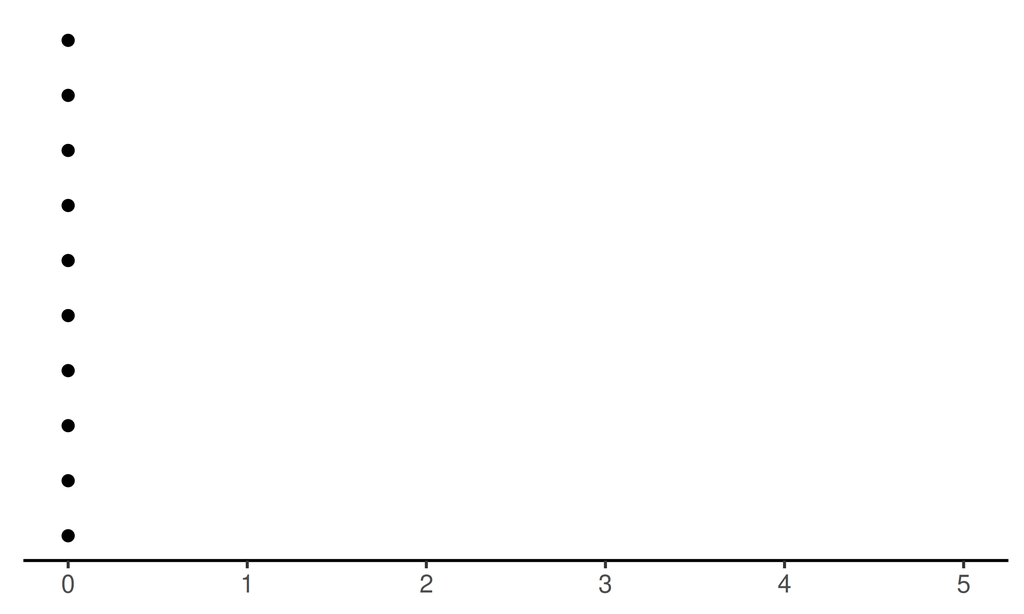

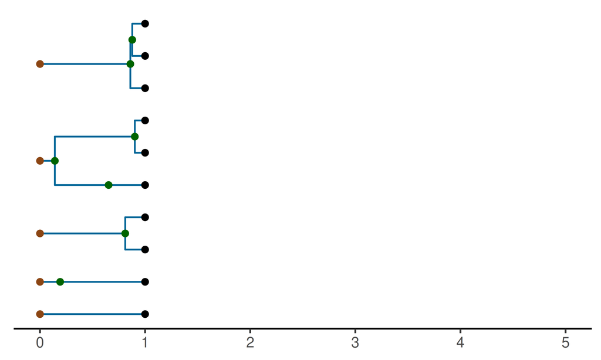

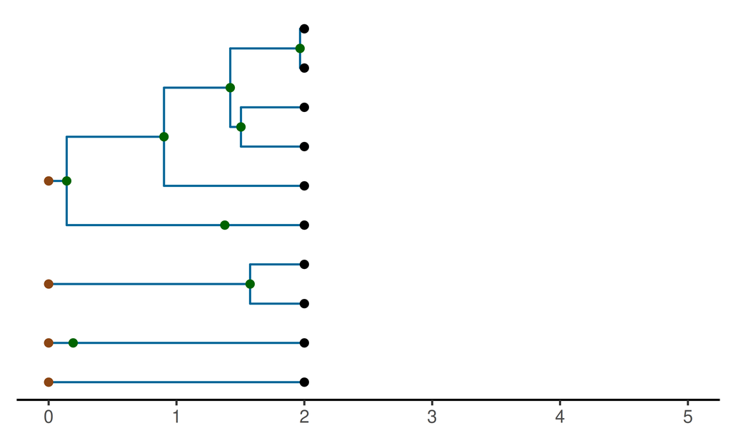

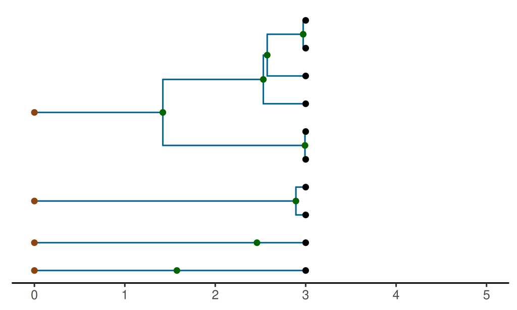

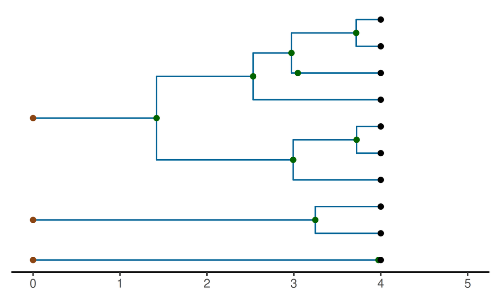

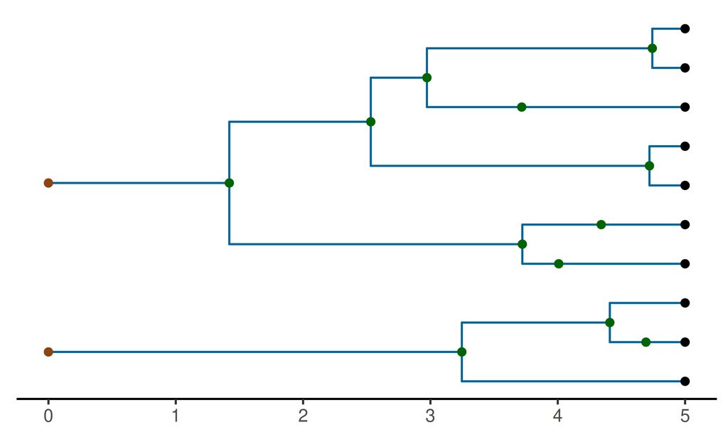

```r
simulate("Moran",time=0,n=10,psi=0) -> m
m |> plot(prune=FALSE,points=TRUE)+expand_limits(x=5)
m |> simulate("Moran",time=1) -> m
m |> plot(prune=FALSE,points=TRUE)+expand_limits(x=5)
m |> simulate("Moran",time=2) -> m
m |> plot(prune=FALSE,points=TRUE)+expand_limits(x=5)
m |> simulate("Moran",time=3) -> m
m |> plot(prune=FALSE,points=TRUE)+expand_limits(x=5)
m |> simulate("Moran",time=4) -> m
m |> plot(prune=FALSE,points=TRUE)+expand_limits(x=5)
m |> simulate("Moran",time=5) -> m
m |> plot(prune=FALSE,points=TRUE)+expand_limits(x=5)
```

In the plots, the black dots correspond to extant lineages. Green dots demarcate the coalescence events (branch points). Brown dots denote the *roots* of the genealogical trees.

### Animating the Moran genealogy process

An animation gives a better sense of the nature of the genealogy process. The following codes repeatedly continue and plot the simulation, storing the result as a list, `pl`, of plots.

```r
bake(
  seed=2147460505,
  file="moran1.rds",
  {
    simulate("Moran",t0=0,time=0,n=10,psi=0) -> m
    times <- seq(0,10,by=0.1)
    pl <- vector(mode="list",length=length(times))
    for (i in seq_along(times)) {
      m |> simulate("Moran",time=times[i]) -> m
      m |>
        plot(prune=FALSE,points=TRUE)+
        expand_limits(x=max(times)) -> pl[[i]]
    }
    pl
  }
) -> pl
```

What is this `bake` function?

In the following chunk, the sourced script defines the `animator` function. This constructs animations in one or more commonly used formats. You can view these files using a web browser or other software you have installed on your system. In an **Rstudio** session, you can also do `file.show("moran1.gif")` to display the animation.

```r
source("https://kingaa.github.io/serrapilheira/phylo/animator.R")
animator(plots=pl,gif_file="figs/moran1.gif",webm=TRUE,mp4=TRUE)
```

[video not shown]

### Exercise

Explore the effect of changing the population size, $n$. Be sure to run the simulations long enough so that the population has a unique common ancestor. How does this affect the time it takes for the whole population to reach this state? How does it affect the shape of the tree?

## Linear birth-death process

Another class of approaches to phylodynamic inference is based on the linear birth-death process (Stadler 2010). In this model, a population of $n_t$ individuals evolves according to the simplest possible demography: individuals give birth at rate $\lambda$ and die at rate $\mu$.

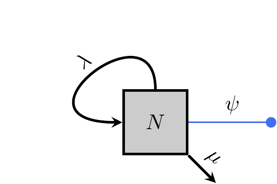

Importantly, in this model, the population size is no longer constant: even if $\lambda=\mu$, $n_t$ will fluctuate stochastically. In particular, the population will go extinct with probablity 1, though if $\lambda>\mu$, it will become very large before it is extinguished, with nonzero probability. Indeed, the expected population size grows (or decays) exponentially in time: $\mathbb{E}\left[{n_t}\;\middle\vert\;{n_0}\right]=n_0\,e^{(\lambda-\mu)\,t}$.

Following Stadler (2010), we allow for constant-rate sampling in this process. Specifically, each lineage is sampled at a rate $\psi$. These samples are indicated as blue dots in the genealogical trees.

The linear birth-death genealogy process is implemented in **phylopomp**. Executing `?lbdp` reveals the following.

[interactive chart not shown]

### Without sampling

As before, we can generate animations to visualize the linear birth-death genealogy process. First, we show a simulation without sampling. In the following, the RNG seed is carefully controlled, ensuring that, in this realization, the population does not die out immediately.

```r
bake(
  seed=239863857,
  file="lbdp1.rds",
  {
    simulate("LBDP",t0=0,time=0,n=1,lambda=1.8,mu=1,psi=0) -> bd
    times <- seq(0,10,by=0.1)
    pl <- vector(mode="list",length=length(times))
    for (i in seq_along(times)) {
      bd |> simulate("LBDP",time=times[i]) -> bd
      bd |>
        plot(prune=FALSE,points=TRUE)+
        expand_limits(x=max(times)) -> pl[[i]]
    }
    animator(plots=pl,gif_file="figs/lbdp1.gif",webm=TRUE,mp4=TRUE)
  }
)
```

[video not shown]

### With sampling

Now we introduce sampling, by making $\psi>0$.

```r
bake(
  seed=1282680647,
  file="lbdp2.rds",
  {
    simulate("LBDP",t0=0,time=0,n=1,lambda=1.4,mu=1,psi=0.5) -> bd
    times <- seq(0,10,by=0.1)
    pl <- vector(mode="list",length=length(times))
    for (i in seq_along(times)) {
      bd |> simulate("LBDP",time=times[i]) -> bd
      bd |>
        plot(prune=FALSE,points=TRUE)+
        expand_limits(x=max(times)) -> pl[[i]]
    }
    animator(plots=pl,gif_file="figs/lbdp2.gif",webm=TRUE,mp4=TRUE)
  }
)
```

[video not shown]

### The pruned linear birth-death-sampling genealogy process

To *prune* the genealogy, is to discard all unsampled lineages. The following shows the same process as above, with pruning.

```r
bake(
  seed=1282680647,
  file="lbdp3.rds",
  {
    simulate("LBDP",t0=0,time=0,n=1,lambda=1.4,mu=1,psi=0.5) -> bd
    times <- seq(0,10,by=0.1)
    pl <- vector(mode="list",length=length(times))
    for (i in seq_along(times)) {
      bd |> simulate("LBDP",time=times[i]) -> bd
      bd |>
        plot(prune=TRUE,points=TRUE)+
        expand_limits(x=max(times)) -> pl[[i]]
    }
    animator(plots=pl,gif_file="figs/lbdp3.gif",webm=TRUE,mp4=TRUE)
  }
)
```

[video not shown]

### Exercise

A convenient feature of the linear birth-death genealogy process (and the reason for its widespread use in phylodynamic inference) is its *self-similarity*. Any subtree is statistically identical to any other subtree, and to the tree as a whole. Look for this property in snapshots of simulations.

## SIR process

The first model that has the key features of a real disease-transmission process is the SIR genealogy process. This is the genealogy process induced by the simple SIR model.

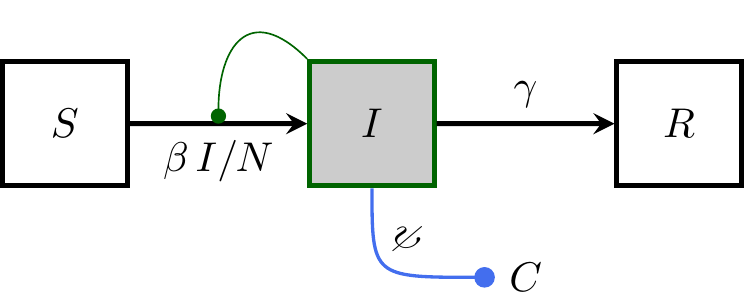

The uniformly-sampled version of this model is implemented in **phylopomp**. Executing `?sir` reveals the following.

[interactive chart not shown]

### Without sampling

```r
bake(
  seed=1282680647,
  file="sir1.rds",
  {
    simulate(
      "SIR",t0=0,time=0,
      S0=200,I0=3,R0=0,
      Beta=2,gamma=1,psi=0
    ) -> sir
    times <- seq(0,10,by=0.1)
    pl <- vector(mode="list",length=length(times))
    for (i in seq_along(times)) {
      sir |> simulate("SIR",time=times[i]) -> sir
      sir |>
        plot(prune=FALSE,points=TRUE)+
        expand_limits(x=max(times)) -> pl[[i]]
    }
    animator(plots=pl,gif_file="figs/sir1.gif",webm=TRUE,mp4=TRUE)
  }
)
```

[video not shown]

### With sampling

```r
bake(
  seed=1282680647,
  file="sir2.rds",
  {
    simulate(
      "SIR",t0=0,time=0,
      S0=200,I0=3,R0=0,
      Beta=2,gamma=1,psi=0.2
    ) -> sir
    times <- seq(0,10,by=0.1)
    pl <- vector(mode="list",length=length(times))
    for (i in seq_along(times)) {
      sir |> simulate("SIR",time=times[i]) -> sir
      sir |>
        plot(prune=FALSE,points=TRUE)+
        expand_limits(x=max(times)) -> pl[[i]]
    }
    animator(plots=pl,gif_file="figs/sir2.gif",webm=TRUE,mp4=TRUE)
  }
)
```

[video not shown]

### The pruned SIR process

```r
bake(
  seed=1282680647,
  file="sir3.rds",
  {
    simulate(
      "SIR",t0=0,time=0,
      S0=300,I0=3,R0=0,
      Beta=2,gamma=1,psi=0.2
    ) -> sir
    times <- seq(0,12,by=0.1)
    pl <- vector(mode="list",length=length(times))
    for (i in seq_along(times)) {
      sir |> simulate("SIR",time=times[i]) -> sir
      sir |>
        plot(prune=TRUE,points=TRUE)+
        expand_limits(x=max(times)) -> pl[[i]]
    }
    animator(plots=pl,gif_file="figs/sir3.gif",webm=TRUE,mp4=TRUE)
  }
)
```

[video not shown]

### Exercise

Study the pruned SIR process by looking at the animation above in detail. The pruned process is Markov. Can you see why this is?

### Exercise

Perform simulations to see how the shape of the simulated trees changes as you vary the parameters. In particular, vary the transmission rate, $\beta$, and the recovery rate, $\gamma$, keeping the sampling rate, $\psi$ fixed. It will be sufficient here to examine snapshots of the genealogy process at a few fixed times.

After you have performed some simulations at a few of the parameters, formulate a hypothesis about the dependence and test it with simulations in new parameter regimes.

## SIRS process

If we allow immunity to be impermanent, i.e., to *wane*, then the SIR model becomes the so-called SIRS model. We can simulate the genealogy process induced by an SIRS population model using the SIR simulator by simply setting $\omega>0$.

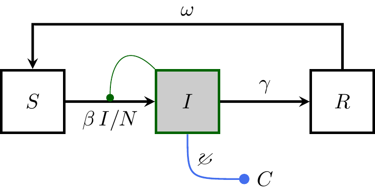

### Exercise

Perform simulations of the SIRS genealogy process and make plots (or even animations) of it. How do the shapes of the genealogies change when we allow for loss of immunity?

## SEIRS process

In passing from an SIRS to an SEIRS population process, we insert an *incubation period*, reflecting the fact that some time must pass before an infection within a host develops to the point that transmission is possible.

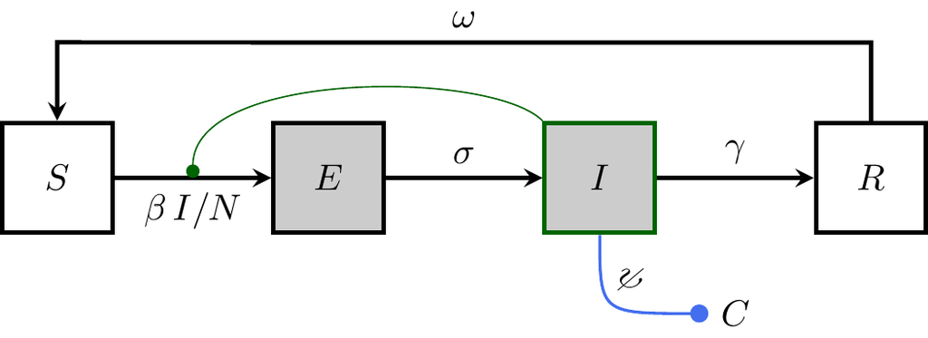

[interactive chart not shown]

### Exercise

Perform simulations of the SEIR genealogy process (i.e., with $\omega=0$) and make plots (or even animations) of it. How do the shapes of the genealogies differ from those from the SIR genealogy process?

### Exercise

Perform simulations of the SEIRS genealogy process (i.e., with $\omega>0$) and make plots (or even animations) of it. How do the shapes of the genealogies differ from those from the SIRS genealogy process?

## Competition between two strains

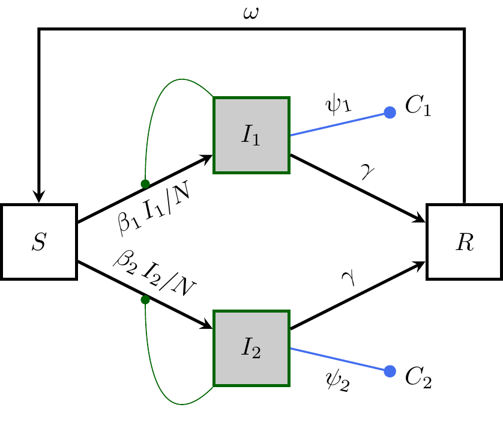

[interactive chart not shown]

### Exercise

State a hypothesis as to how the shapes of genealogies will change as you vary the $\beta_1$, $\beta_2$ parameters in this two-deme, two-strain genealogy process. Perform simulations and make plots or animations to test your hypothesis.

## A model of superspreading

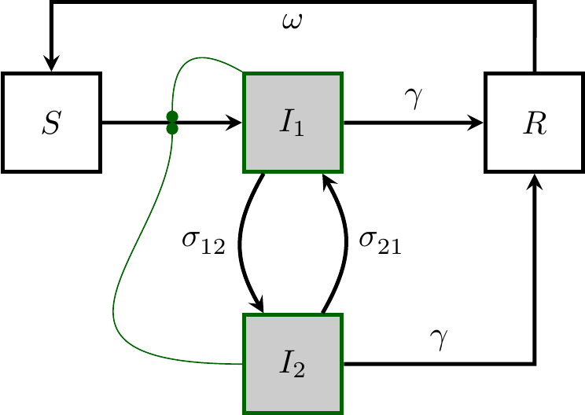

[interactive chart not shown]

### Exercise

State a hypothesis as to how the shapes of pruned genealogies will change as you vary the $\beta_2$ parameter in this two-deme model. Perform simulations and make plots or animations to test your hypothesis. You may find it useful to plot both obscured and unobscured pruned genealogies.

### Exercise

State a hypothesis as to how changing the $\sigma_{12}$ and $\sigma_{21}$ rates will affect the shapes of genealogies. Perform simulations and make plots or animations to test your hypothesis.

Produced in **R** version 4.3.2 using **phylopomp** version 0.10.3.0.

## References

Grenfell BT, Pybus OG, Gog JR, Wood JLN, Daly JM, Mumford JA, Holmes EC (2004). “Unifying the Epidemiological and Evolutionary Dynamics of Pathogens.” *Science*, **303**, 327–332. https://doi.org/10.1126/science.1090727.

King AA, Lin Q, Ionides EL (2020). “The Sampled Moran Genealogy Process.” *arXiv*, https://doi.org/10.48550/arXiv.2002.11184.

Kingman JFC (1982a). “On the Genealogy of Large Populations.” *J. Appl. Probab.*, **19**, 27–43. https://doi.org/10.2307/3213548.

Kingman JFC (1982b). “The Coalescent.” *Stochastic Process. Appl.*, **13**(3), 235–248. https://doi.org/10.1016/0304-4149(82)90011-4.

Moran PAP (1958). “Random Processes in Genetics.” *Math. Proc. Cambridge Philos. Soc.*, **54**(1), 60–71. https://doi.org/10.1017/s0305004100033193.

Rasmussen DA, Ratmann O, Koelle K (2011). “Inference for Nonlinear Epidemiological Models Using Genealogies and Time Series.” *PLoS Comput. Biol.*, **7**(8), e1002136. https://doi.org/10.1371/journal.pcbi.1002136.

Stadler T (2010). “Sampling-Through-Time in Birth-Death Trees.” *J. Theor. Biol.*, **267**(3), 396–404. https://doi.org/10.1016/j.jtbi.2010.09.010.

Volz EM, Kosakovsky Pond SL, Ward MJ, Leigh Brown AJ, Frost SDW (2009). “Phylodynamics of Infectious Disease Epidemics.” *Genetics*, **183**(4), 1421–1430. https://doi.org/10.1534/genetics.109.106021.

Licensed under the [Creative Commons Attribution-NonCommercial license](http://creativecommons.org/licenses/by-nc/4.0/). Please share and remix noncommercially, mentioning its origin.